# Regression Project

Pat Ballard, Brent Lodge, Sean Morey

Spring 2018

### Part 1: Importing and Examining Data

#### 1.1 Importing Data

```r
comm_prop <- read_csv("comm_prop.csv")
comm_prop$W2MiDT <- factor(comm_prop$W2MiDT, levels = c(0, 1), labels = c("No","Yes"))
summary(comm_prop)
```

```
##     RentRate          Age           OperExp          VacRate
##  Min.   :10.50   Min.   : 0.00   Min.   : 3.000   Min.   :0.0000
##  1st Qu.:14.00   1st Qu.: 2.00   1st Qu.: 7.997   1st Qu.:0.0000
##  Median :15.00   Median : 4.00   Median :10.370   Median :0.0400
##  Mean   :15.13   Mean   : 8.01   Mean   : 9.658   Mean   :0.0801
##  3rd Qu.:16.50   3rd Qu.:15.00   3rd Qu.:11.660   3rd Qu.:0.0925
##  Max.   :19.25   Max.   :20.00   Max.   :14.620   Max.   :0.7300
##       SqFt            Taxes       W2MiDT
##  Min.   : 27000   Min.   :0.490   No :64
##  1st Qu.: 73141   1st Qu.:1.315   Yes:36
##  Median :129614   Median :2.330
##  Mean   :166101   Mean   :2.990
##  3rd Qu.:244546   3rd Qu.:4.402
##  Max.   :484290   Max.   :8.720
```

```r
attach(comm_prop)
```

#### 1.2 Examining Variable Distribution

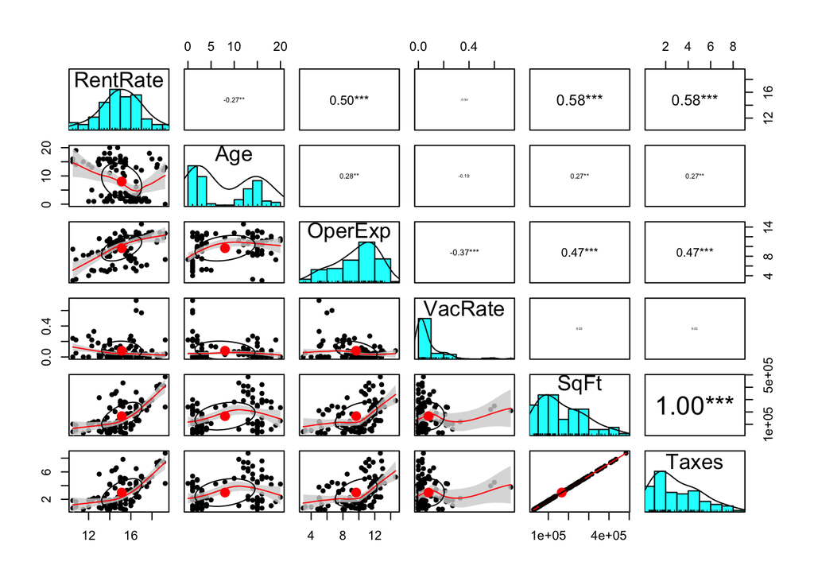

```r
pairs.panels(comm_prop[,c(1:6)], scale=TRUE, ci =T, stars = T)
```

This plot gives a number of different observations; RentRate *appears* to be a relatively normal distribution, while all others appear skewed in some way. Age has a gap between 5 and 10 years, possibly indicating some sort of recession where building came to a halt. SqFt and Taxes are skewed identically to the right. While W2MiDT is not a continuous variable, there are more buildings in this sample outside of 2 miles than within, posibbly indicating some sort of urban sprawl in this city.

#### 1.3 Examining Correlations

```r
M <- cor(comm_prop[,c(1:6)])
M
```

```
##             RentRate        Age    OperExp     VacRate       SqFt
## RentRate  1.00000000 -0.2717822  0.4961736 -0.03718869 0.58440930
## Age      -0.27178219  1.0000000  0.2807262 -0.18660828 0.26929259
## OperExp   0.49617362  0.2807262  1.0000000 -0.36605714 0.46658357
## VacRate  -0.03718869 -0.1866083 -0.3660571  1.00000000 0.02947991
## SqFt      0.58440930  0.2692926  0.4665836  0.02947991 1.00000000
## Taxes     0.58452951  0.2691128  0.4663997  0.02944071 0.99999918
##               Taxes
## RentRate 0.58452951
## Age      0.26911276
## OperExp  0.46639966
## VacRate  0.02944071
## SqFt     0.99999918
## Taxes    1.00000000
```

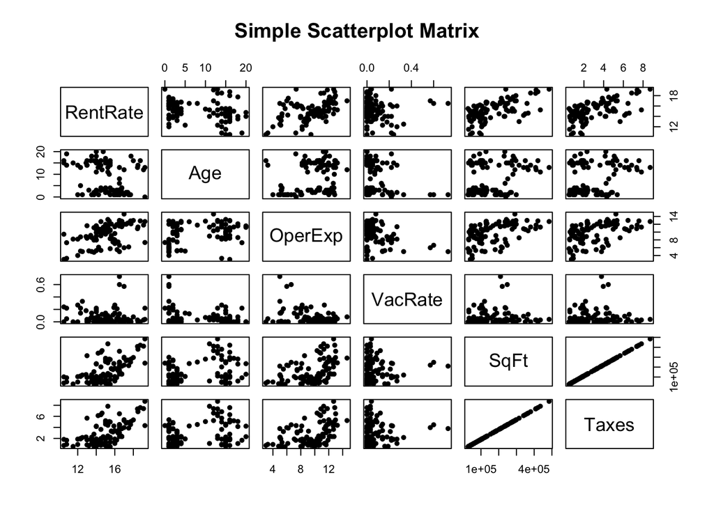

```r
pairs(comm_prop[,1:6], main="Simple Scatterplot Matrix", pch = 16)
```

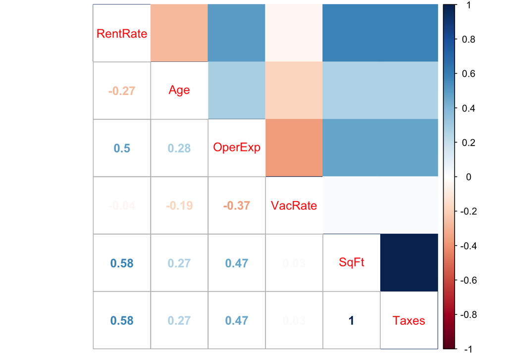

```r
corrplot.mixed(M, upper = "color")
```

Using these plots along with the “pairs.panels” plot from 1.2, we can see that correlations for *continuous* variables are pretty widely varied. The VacRate variable does not correlate well with any other variable (besides a slight negative correlation with OperExp). SqFt and Taxes are perfectly correlated, and they both have a .58 correlation with RentRate (the highest among continuous variables). OperExp has a .5 correlation to RentRate. Age has a small negative correlation, but looking at the scatter plot there may be a way to split that data into factors or ignore some of it to get a stronger correlation.

### Part 2: Making a Model

#### 2.1: Undertand the Data

Using the info from the previous sections we can see there are no missing values. The histograms from 1.2 show that Age has a severe split; lets look at that one specifically:

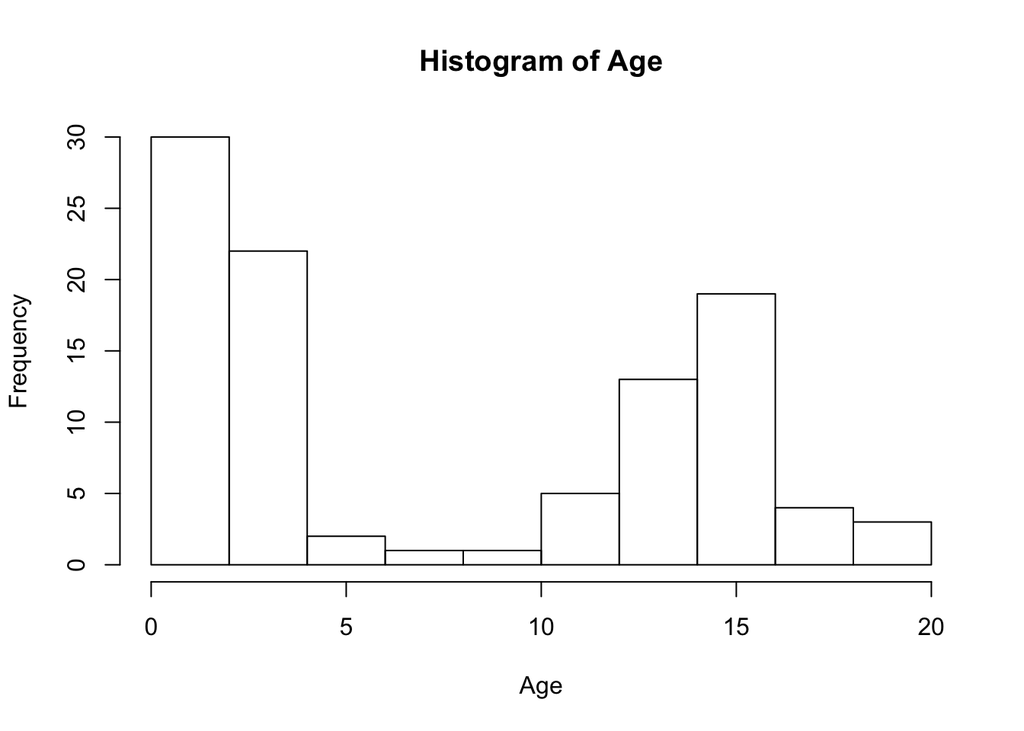

```r
hist(Age)
```

Since our building is 9 years old, the cost of rent will correlate more strongly with the group of buildings aged 9 years and older. We decided to fit a model with all variables included first, but after fitting a decent model we plan to exclude buildings <= 9 years old.

### 3: Fit a Model

#### 3.1: Determine variables and data manipulations

We ran a model on the entire data frame just to see some basic data.

```r
fit1 <- lm(comm_prop)
summary(fit1)
```

```
##
## Call:
## lm(formula = comm_prop)
##
## Residuals:
##      Min       1Q   Median       3Q      Max
## -2.65450 -0.59760 -0.02213  0.65394  2.57988
##
## Coefficients:
##               Estimate Std. Error t value Pr(>|t|)
## (Intercept) 12.2278960  0.4483644  27.272  < 2e-16 ***
## Age         -0.1040412  0.0185484  -5.609 2.08e-07 ***
## OperExp      0.2255069  0.0497984   4.528 1.76e-05 ***
## VacRate     -0.7568956  0.9114326  -0.830    0.408
## SqFt        -0.0005652  0.0007194  -0.786    0.434
## Taxes       31.7633824 39.9476685   0.795    0.429
## W2MiDTYes    1.4434308  0.2586992   5.580 2.36e-07 ***
## ---
## Signif. codes:  0 '***' 0.001 '**' 0.01 '*' 0.05 '.' 0.1 ' ' 1
##
## Residual standard error: 0.9884 on 93 degrees of freedom
## Multiple R-squared:  0.7463, Adjusted R-squared:   0.73
## F-statistic: 45.61 on 6 and 93 DF,  p-value: < 2.2e-16
```

```r
mc <- vif(fit1)
summary(fit1)
```

```
##
## Call:
## lm(formula = comm_prop)
##
## Residuals:
##      Min       1Q   Median       3Q      Max
## -2.65450 -0.59760 -0.02213  0.65394  2.57988
##
## Coefficients:
##               Estimate Std. Error t value Pr(>|t|)
## (Intercept) 12.2278960  0.4483644  27.272  < 2e-16 ***
## Age         -0.1040412  0.0185484  -5.609 2.08e-07 ***
## OperExp      0.2255069  0.0497984   4.528 1.76e-05 ***
## VacRate     -0.7568956  0.9114326  -0.830    0.408
## SqFt        -0.0005652  0.0007194  -0.786    0.434
## Taxes       31.7633824 39.9476685   0.795    0.429
## W2MiDTYes    1.4434308  0.2586992   5.580 2.36e-07 ***
## ---
## Signif. codes:  0 '***' 0.001 '**' 0.01 '*' 0.05 '.' 0.1 ' ' 1
##
## Residual standard error: 0.9884 on 93 degrees of freedom
## Multiple R-squared:  0.7463, Adjusted R-squared:   0.73
## F-statistic: 45.61 on 6 and 93 DF,  p-value: < 2.2e-16
```

```r
mc
```

```
##          Age      OperExp      VacRate         SqFt        Taxes
## 1.471054e+00 1.738089e+00 1.303177e+00 6.594820e+05 6.593269e+05
##       W2MiDT
## 1.578436e+00
```

Now that we have confirmed the multicollinearity of SqFt and Taxes, we will remove Taxes (to avoid the multicollinearity) and VacRate (due to insignificant p-value). Our F-statistic is 45.61 and the adjusted R-squared = 0.73. We will compare our other models to these statistics.

```r
fit2 <- lm(RentRate~Age+OperExp+SqFt+W2MiDT)
summary(fit2)
```

```
##
## Call:
## lm(formula = RentRate ~ Age + OperExp + SqFt + W2MiDT)
##
## Residuals:
##      Min       1Q   Median       3Q      Max
## -2.90483 -0.58081 -0.03454  0.57347  2.54837
##
## Coefficients:
##               Estimate Std. Error t value Pr(>|t|)
## (Intercept)  1.205e+01  3.789e-01  31.797  < 2e-16 ***
## Age         -1.040e-01  1.843e-02  -5.641 1.74e-07 ***
## OperExp      2.373e-01  4.406e-02   5.385 5.22e-07 ***
## SqFt         6.643e-06  1.112e-06   5.975 3.98e-08 ***
## W2MiDTYes    1.435e+00  2.539e-01   5.653 1.65e-07 ***
## ---
## Signif. codes:  0 '***' 0.001 '**' 0.01 '*' 0.05 '.' 0.1 ' ' 1
##
## Residual standard error: 0.986 on 95 degrees of freedom
## Multiple R-squared:  0.7421, Adjusted R-squared:  0.7313
## F-statistic: 68.35 on 4 and 95 DF,  p-value: < 2.2e-16
```

```r
comm_prop_age9 <- subset(comm_prop, Age>9)
attach(comm_prop)
detach(comm_prop)
attach(comm_prop_age9)
summary(comm_prop_age9)
```

```
##     RentRate          Age           OperExp         VacRate
##  Min.   :10.50   Min.   :10.00   Min.   : 3.00   Min.   :0.00000
##  1st Qu.:13.40   1st Qu.:13.00   1st Qu.: 8.97   1st Qu.:0.00000
##  Median :14.50   Median :15.00   Median :10.77   Median :0.04000
##  Mean   :14.64   Mean   :14.87   Mean   :10.41   Mean   :0.06178
##  3rd Qu.:15.50   3rd Qu.:16.00   3rd Qu.:11.80   3rd Qu.:0.08000
##  Max.   :19.25   Max.   :20.00   Max.   :14.62   Max.   :0.27000
##       SqFt            Taxes       W2MiDT
##  Min.   : 30005   Min.   :0.540   No :36
##  1st Qu.: 99500   1st Qu.:1.790   Yes: 9
##  Median :201930   Median :3.630
##  Mean   :208508   Mean   :3.753
##  3rd Qu.:296966   3rd Qu.:5.350
##  Max.   :484290   Max.   :8.720
```

```r
str(comm_prop_age9)
```

```
## Classes 'tbl_df', 'tbl' and 'data.frame':    45 obs. of  7 variables:
##  $ RentRate: num  12 10.5 14 10.5 17 ...
##  $ Age     : int  14 16 11 15 12 13 12 16 14 15 ...
##  $ OperExp : num  8.19 3 8.97 9.45 14.62 ...
##  $ VacRate : num  0.27 0 0.07 0.24 0.08 0.04 0.12 0 0 0.05 ...
##  $ SqFt    : int  104079 39998 60000 101385 291264 359665 366013 349930 45959 81243 ...
##  $ Taxes   : num  1.87 0.72 1.08 1.82 5.24 6.47 6.59 6.3 0.83 1.46 ...
##  $ W2MiDT  : Factor w/ 2 levels "No","Yes": 1 1 1 1 2 1 1 1 1 1 ...
```

Our new data frame has 45 observations. Lets fit a model using the variables we decided on in our previous fit. &nbsp

```r
fit4 <- lm(RentRate~OperExp+SqFt+W2MiDT)
summary(fit4)
```

```
##
## Call:
## lm(formula = RentRate ~ OperExp + SqFt + W2MiDT)
##
## Residuals:
##     Min      1Q  Median      3Q     Max
## -2.9221 -0.6103  0.1917  0.6324  2.8569
##
## Coefficients:
##              Estimate Std. Error t value Pr(>|t|)
## (Intercept) 8.867e+00  8.216e-01  10.792 1.50e-13 ***
## OperExp     4.059e-01  9.205e-02   4.410 7.31e-05 ***
## SqFt        5.431e-06  1.718e-06   3.162  0.00295 **
## W2MiDTYes   2.064e+00  4.711e-01   4.382 7.98e-05 ***
## ---
## Signif. codes:  0 '***' 0.001 '**' 0.01 '*' 0.05 '.' 0.1 ' ' 1
##
## Residual standard error: 1.106 on 41 degrees of freedom
## Multiple R-squared:  0.7772, Adjusted R-squared:  0.7609
## F-statistic: 47.68 on 3 and 41 DF,  p-value: 1.972e-13
```

This fit is better based on R-squared, but not by much. Additionally our F-Statistic dropped some. Our group examined the data and thought that VacRate may still be useful in our regression. Additionally, we thought that W2MiDT and SqFt would be interesting to use as interacting variables. Our thought process was that buildings with large square footage that were *also* downtown would be more desirable than buildings with large square footage that were *not* downtown.

```r
fit5 <- lm(RentRate~OperExp+W2MiDT*SqFt+VacRate)
summary(fit5)
```

```
##
## Call:
## lm(formula = RentRate ~ OperExp + W2MiDT * SqFt + VacRate)
##
## Residuals:
##     Min      1Q  Median      3Q     Max
## -1.8405 -0.6321  0.0488  0.4978  2.0372
##
## Coefficients:
##                  Estimate Std. Error t value Pr(>|t|)
## (Intercept)     9.845e+00  6.520e-01  15.100  < 2e-16 ***
## OperExp         4.173e-01  6.969e-02   5.989 5.37e-07 ***
## W2MiDTYes      -1.777e+00  8.421e-01  -2.110 0.041347 *
## SqFt            1.975e-06  1.464e-06   1.349 0.185233
## VacRate        -6.870e+00  1.893e+00  -3.629 0.000816 ***
## W2MiDTYes:SqFt  1.222e-05  2.552e-06   4.787 2.45e-05 ***
## ---
## Signif. codes:  0 '***' 0.001 '**' 0.01 '*' 0.05 '.' 0.1 ' ' 1
##
## Residual standard error: 0.8309 on 39 degrees of freedom
## Multiple R-squared:  0.8804, Adjusted R-squared:  0.8651
## F-statistic: 57.41 on 5 and 39 DF,  p-value: < 2.2e-16
```

Success! Our adjusted R-squared value rose to a 0.87 and our F-statistic gained back 10 points. The p-value is the smallest R will support. This is the model we chose to proceed with. Lets proceed with some tests to verify normality and constant variance.

#### Section 3.2: Test the resulting model

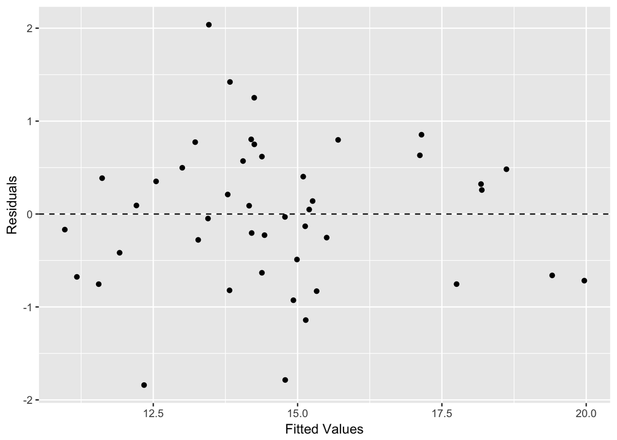

```r
fit5.df <- fortify(fit5)
ggplot(fit5.df, aes(x= .fitted, y= .resid)) +
  geom_point() +
  geom_hline(yintercept = 0, linetype = 2) +
  labs(x = "Fitted Values", y = "Residuals")
```

```r
ncvTest(fit5)
```

```
## Non-constant Variance Score Test
## Variance formula: ~ fitted.values
## Chisquare = 0.5361141    Df = 1     p = 0.4640476
```

```r
shapiro.test(fit5$residuals)
```

```
##
##  Shapiro-Wilk normality test
##
## data:  fit5$residuals
## W = 0.98554, p-value = 0.8393
```

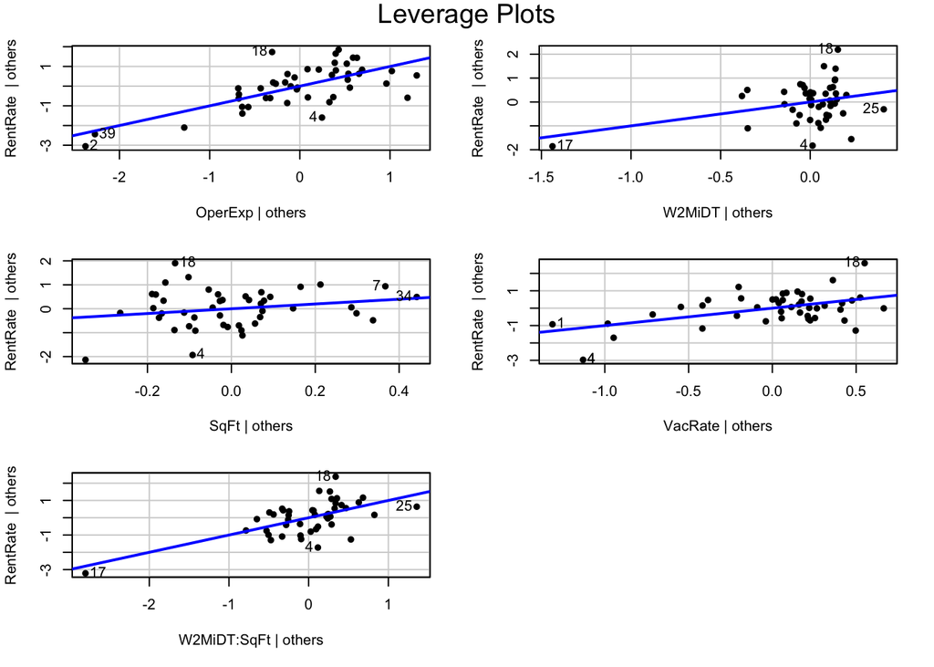

```r
leveragePlots(fit5, pch = 16)
```

The residuals appear to have random distribution. The leverage plots appear *largely* normal. There may be a few outliers but none appear to be leveraging our model too badly. The ncv test shows an insignificant p-value, indicating that we do *not* reject the null hypothesis that the error variance is constant. The shapiro test has high W and p-values indicating that we found no significant departure from normality.

Our coefficients, t-values, and p-values for each variable are as follows;

```r
summary(fit5)
```

```
##
## Call:
## lm(formula = RentRate ~ OperExp + W2MiDT * SqFt + VacRate)
##
## Residuals:
##     Min      1Q  Median      3Q     Max
## -1.8405 -0.6321  0.0488  0.4978  2.0372
##
## Coefficients:
##                  Estimate Std. Error t value Pr(>|t|)
## (Intercept)     9.845e+00  6.520e-01  15.100  < 2e-16 ***
## OperExp         4.173e-01  6.969e-02   5.989 5.37e-07 ***
## W2MiDTYes      -1.777e+00  8.421e-01  -2.110 0.041347 *
## SqFt            1.975e-06  1.464e-06   1.349 0.185233
## VacRate        -6.870e+00  1.893e+00  -3.629 0.000816 ***
## W2MiDTYes:SqFt  1.222e-05  2.552e-06   4.787 2.45e-05 ***
## ---
## Signif. codes:  0 '***' 0.001 '**' 0.01 '*' 0.05 '.' 0.1 ' ' 1
##
## Residual standard error: 0.8309 on 39 degrees of freedom
## Multiple R-squared:  0.8804, Adjusted R-squared:  0.8651
## F-statistic: 57.41 on 5 and 39 DF,  p-value: < 2.2e-16
```

```r
qf(p = 0.05, df1 = 1, df2 = 43)
```

```
## [1] 0.003978309
```

```r
summary(aov(comm_prop_age9$RentRate ~ comm_prop_age9$W2MiDT))
```

```
##                       Df Sum Sq Mean Sq F value   Pr(>F)
## comm_prop_age9$W2MiDT  1  97.94   97.94   33.11 8.31e-07 ***
## Residuals             43 127.18    2.96
## ---
## Signif. codes:  0 '***' 0.001 '**' 0.01 '*' 0.05 '.' 0.1 ' ' 1
```

Given our qf function gave us a target F-value of 0.004 and Anova produced an F-value of 33.11, we conclude (with 95% confidence) that the mean rent rate of buildings within 2 miles of downtown and buildings *not* within 2 miles of downtown differ. We believe that the adjusted R-Squared value of 0.87 is more than high enough to be confident in our predictive tests. The data set provided was relatively useful, but we would have liked to see several more variables. For one, the W2MiDT variable could have been better as a continuous numeric value in miles. We would have also liked to have variables for the number of floors in a building, the amount of parking available, and some way to indicate available ammenities like gas lines, internet, pools and community areas.

### Extra Credit

#### Backwards Stepwise Regression

```r
library(MASS)
stepAIC(lm(RentRate~Age+W2MiDT+SqFt+OperExp+VacRate), direction = 'backward')
```

```
## Start:  AIC=8.86
## RentRate ~ Age + W2MiDT + SqFt + OperExp + VacRate
##
##           Df Sum of Sq    RSS     AIC
## - Age      1    0.7814 42.744  7.6854
## <none>                 41.962  8.8551
## - VacRate  1    8.0930 50.056 14.7912
## - SqFt     1    9.0479 51.010 15.6415
## - W2MiDT   1   18.6891 60.652 23.4318
## - OperExp  1   21.7790 63.741 25.6678
##
## Step:  AIC=7.69
## RentRate ~ W2MiDT + SqFt + OperExp + VacRate
##
##           Df Sum of Sq    RSS     AIC
## <none>                 42.744  7.6854
## - VacRate  1    7.4038 50.148 12.8739
## - SqFt     1   11.5432 54.287 16.4431
## - W2MiDT   1   18.7419 61.486 22.0465
## - OperExp  1   21.4630 64.207 23.9952
```

```
##
## Call:
## lm(formula = RentRate ~ W2MiDT + SqFt + OperExp + VacRate)
##
## Coefficients:
## (Intercept)    W2MiDTYes         SqFt      OperExp      VacRate
##   9.516e+00    1.870e+00    5.280e-06    3.869e-01   -6.182e+00
```

```r
fit6 <- lm(formula = RentRate ~ W2MiDT + SqFt + OperExp + VacRate)
summary(fit6)
```

```
##
## Call:
## lm(formula = RentRate ~ W2MiDT + SqFt + OperExp + VacRate)
##
## Residuals:
##     Min      1Q  Median      3Q     Max
## -3.2176 -0.6612  0.1647  0.5369  2.3760
##
## Coefficients:
##               Estimate Std. Error t value Pr(>|t|)
## (Intercept)  9.516e+00  8.067e-01  11.797 1.34e-14 ***
## W2MiDTYes    1.870e+00  4.465e-01   4.188  0.00015 ***
## SqFt         5.280e-06  1.607e-06   3.287  0.00212 **
## OperExp      3.869e-01  8.634e-02   4.482 6.07e-05 ***
## VacRate     -6.182e+00  2.349e+00  -2.632  0.01200 *
## ---
## Signif. codes:  0 '***' 0.001 '**' 0.01 '*' 0.05 '.' 0.1 ' ' 1
##
## Residual standard error: 1.034 on 40 degrees of freedom
## Multiple R-squared:  0.8101, Adjusted R-squared:  0.7911
## F-statistic: 42.67 on 4 and 40 DF,  p-value: 6.38e-14
```

This function might be more valuable if we were to use second order terms. As is, the F-statistic and adjusted R-squared value are lower than our original function, so we elect not to use backwards stepwise regression. We were asked to go through formal tests for residuals and variance in this model, but I (Sean) did not have time to do that for all our models, so my decision to move forward with fit5 is based soley on R-squared and F-statistic.

#### Best Subsets

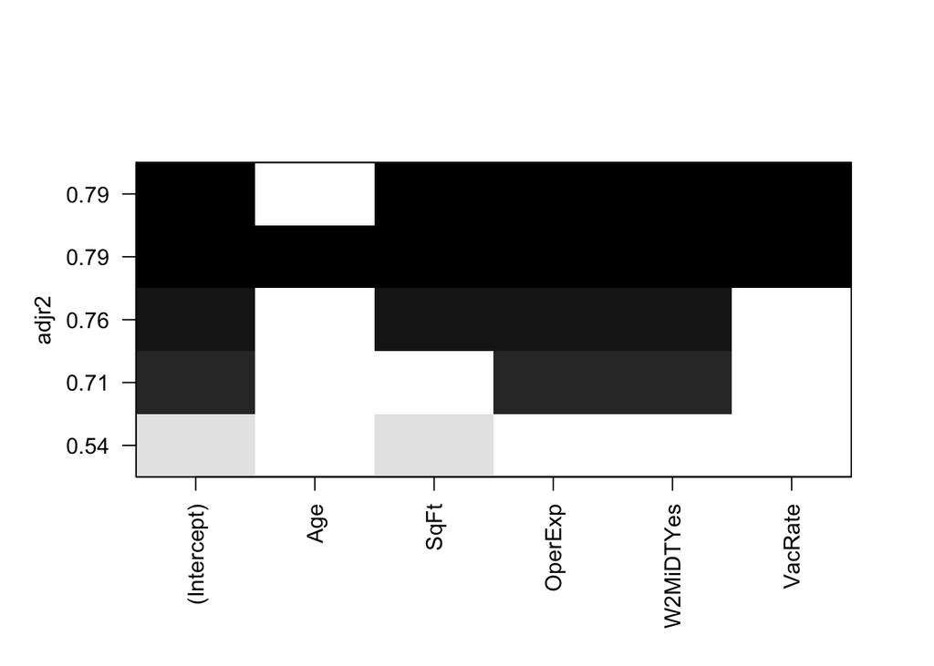

```r
library(leaps)
subsets <- regsubsets(RentRate~Age+SqFt+OperExp+W2MiDT+VacRate, data = comm_prop_age9)
plot(subsets, scale="adjr2")
```

```r
fit7 <- lm(RentRate~SqFt+OperExp+W2MiDT+VacRate, data = comm_prop_age9)
summary(fit7)
```

```
##
## Call:
## lm(formula = RentRate ~ SqFt + OperExp + W2MiDT + VacRate, data = comm_prop_age9)
##
## Residuals:
##     Min      1Q  Median      3Q     Max
## -3.2176 -0.6612  0.1647  0.5369  2.3760
##
## Coefficients:
##               Estimate Std. Error t value Pr(>|t|)
## (Intercept)  9.516e+00  8.067e-01  11.797 1.34e-14 ***
## SqFt         5.280e-06  1.607e-06   3.287  0.00212 **
## OperExp      3.869e-01  8.634e-02   4.482 6.07e-05 ***
## W2MiDTYes    1.870e+00  4.465e-01   4.188  0.00015 ***
## VacRate     -6.182e+00  2.349e+00  -2.632  0.01200 *
## ---
## Signif. codes:  0 '***' 0.001 '**' 0.01 '*' 0.05 '.' 0.1 ' ' 1
##
## Residual standard error: 1.034 on 40 degrees of freedom
## Multiple R-squared:  0.8101, Adjusted R-squared:  0.7911
## F-statistic: 42.67 on 4 and 40 DF,  p-value: 6.38e-14
```

Conveniently, this method produced the SAME MODEL as backwards stepwise regression did. We can reject this model for the same reasons as we did fit6. We will proceed with fit5!

### Section 4: Apply the model

We run our model using the predict function. Our building is 9 years old, has $13k in operating expenses, has had no vacancy, is 40000 sq. ft., has $540 in taxes, and is *not* within 2 miles of downtown.

```r
test.row <- data.frame(Age = 9, OperExp = 13, VacRate = 0, SqFt = 40000, Taxes = .540, W2MiDT = as.factor("No"))
predict(fit5, newdata = test.row, interval = "predict")
```

```
##        fit      lwr      upr
## 1 15.34975 13.48228 17.21722
```

Our prediction is that we can rent our building for $15,350 with $13,480 being the lower bound and $17,220 being the upper bound (at a 95% confidence interval). Since our operating expenses are at $13k (which is below our confidence interval) we can say with 95% confidence that renting our building will *at least* cover our expenses. We should keep the building and rent it.